# Chapter 3 Experiment 1 Analysis

Danielle Burgess

```r
# setup -----
knitr::opts_chunk$set(echo=TRUE, message=FALSE, warning=FALSE, fig.show='hold', results='hold')

library(here) #for file referencing with here()
library(dplyr) # for tidying data
library(boot) #for bootstrap resampling
library(ggplot2) #for graphing
library(buildmer) # for model selection
library(lme4) # for mixed effects regression modeling
library(plotrix) #for std.error()

# local functions -----

# import data from PsychoPy data files, specifying rows
# varNames = a list of the column names you want to include
data.import <- function(file, lowerRow, upperRow, varNames){
  data <- read.csv(file, header=T);
  dataImp <- data[lowerRow:upperRow, varNames]
  return(dataImp)
}

# a function for swapping values in a vector with other values.
swap <- function(vec, from, to) {
  tmp <- to[ match(vec, from) ]
  tmp[is.na(tmp)] <- vec[is.na(tmp)]
  return(tmp)
}

# returns a data frame for our psychopy production data with accuracy column
prod.import <- function(fileNames, lowerRow, upperRow) {
  prod_vars <- c("participant","inputText","Text")
  prod_data <- do.call("rbind", lapply(fileNames, data.import, lowerRow, upperRow, prod_vars))
  #delete every other row
  toDelete <- seq(1, nrow(prod_data), 2)
  prod_data <- prod_data[toDelete,]
  #add col for condition
  prod_data$Condition <- ifelse(grepl("^00",prod_data$participant),"Equiprobable",
                                ifelse(grepl("^01",prod_data$participant),"Majority Preverbal","Majority Postverbal"))
  prod_data$Condition <- as.factor(prod_data$Condition)
  #add col for accuracy
  prod_data$inputText <- as.character(prod_data$inputText)
  prod_data$Text <- as.character(prod_data$Text)
  prod_data$Acc <- ifelse(prod_data$inputText == prod_data$Text, 1, 0)
  return(prod_data)
}

# returns a data frame for our psychopy FCT data with accuracy column
fct.import <-function(fileNames, lowerRow, upperRow) {
  FCT_vars <- c("participant","key_resp_fct.keys","correctans","word")
  FCT_data <- do.call("rbind", lapply(fileNames, data.import, lowerRow, upperRow, FCT_vars))
  #delete every other row
  toDelete <- seq(1, nrow(FCT_data), 2)
  FCT_data <- FCT_data[toDelete,]
  #add col for condition
  FCT_data$Condition <- ifelse(grepl("^00",FCT_data$participant),"Equiprobable",
                           ifelse(grepl("^01",FCT_data$participant),"Majority Preverbal","Majority Postverbal"))
  FCT_data$Condition <- as.factor(FCT_data$Condition)
  #create column for accuracy on task, 1 is correct, 0 is incorrect
  FCT_data$Acc <- ifelse(FCT_data$key_resp_fct.keys == FCT_data$correctans, 1, 0)
  return(FCT_data)
}

#returns se of a vector
se <- function(data) sqrt(var(data)/length(data))

acc.bycondition <- function(data) {
  data2 <- aggregate(data[["Acc"]], list(data[["Condition"]],data[["participant"]]), mean)
  colnames(data2) <- c("Condition","participant","prop")
  data3 <- aggregate(data2$prop, list(data2$Condition), mean)
  colnames(data3) <- c("Condition","mean")
  data4 <- aggregate(data2$prop, list(data2$Condition), sd)
  colnames(data4) <- c("Condition","sd")
  data5 <- join(data3,data4)
  return(data5)
}

id.neg.order <- function(response, NegVSentence, acc) {
  if (acc == 0) {
    NA
  }
  else {
    if (response == NegVSentence) {
      1
    }
    else {
      0
    }
  }
}
```

# 1 Import Data

In the experiment, participants progressed through three rounds of training. First, they were trained on nouns in the language, then affirmative SVO sentences, then negative sentences with both SNegVO and SVNegO word orders. After each round of training, participants completed both a set of forced choice task comprehension trials, where they were presented with a sentence and asked to identify which of two images matched the sentences, and a set of production trials, where they were presented with an image and asked to type the sentence in the artificial language. The final production block included a mixture of both negative sentences and affirmative target sentences.

In this chunk, I create data frames for each of the following testing phases of the experiment:

- Ch3FCT = forced choice task comprehension trials
- Ch3Prod = production trials
- negProd = negative sentence trials from final production phase
- finalProd = all trials from final production phase

```r
## generate list of file names
fileNames <- list.files(path=here::here("raw_data"), pattern = "*.csv",full.names = TRUE)

## import data from intermediate test phases
#import participant production data from psychopy files
nounProd <- prod.import(fileNames,51,74) #noun results
affProd <- prod.import(fileNames,160,183) #aff. sentence results

## import data from final production phase
finalProd_vars <- c("participant","inputText","NegVSentence","VNegSentence","AffSentence","gather_loop.thisIndex")
finalProd <- do.call("rbind", lapply(fileNames, data.import, 277, 312, finalProd_vars))
finalProd <- finalProd %>% rename(item = gather_loop.thisIndex)

## add columns for analysis
# add col for condition
finalProd$Condition <- ifelse(grepl("^00",finalProd$participant),"Equiprobable",
                           ifelse(grepl("^01",finalProd$participant),"Majority NegV","Majority VNeg"))
finalProd$Condition <- as.factor(finalProd$Condition)
# add col identifying whether the trial is negative or affirmative
finalProd$isNeg <- ifelse(grepl("None",finalProd$AffSentence),1,0)
# add col for accuracy
finalProd$VNegSentence[finalProd$VNegSentence == "pepo pik umi ludin"] <- "pepo umi pik ludin" #correct error
finalProd <- finalProd %>%
  mutate(Acc = case_when(
    finalProd$inputText == finalProd$AffSentence ~ 1,
    finalProd$inputText == finalProd$NegVSentence ~ 1,
    finalProd$inputText == finalProd$VNegSentence ~ 1
  ))
finalProd$Acc[is.na(finalProd$Acc)] = 0

## separate out negative sentence productions
negProd <- finalProd %>% filter(isNeg==1)

#label production phases
nounProd$phase <- "NounProd"
affProd$phase <- "AffProd"
finalProd$phase <- "FinalProd"
Ch3Prod <- bind_rows(nounProd,affProd,finalProd)
remove(nounProd,affProd)
```

```r
#import participant 2AFC data from psychopy files
nounFCT <- fct.import(fileNames,27,50) #noun results
affFCT <- fct.import(fileNames,148,159) #aff. sentence results
finalFCT <- fct.import(fileNames,257,276) #review results

#label FCT phases
nounFCT$phase <- "NounFCT"
affFCT$phase <- "AffFCT"
finalFCT$phase <- "ReviewFCT"

Ch3FCT <- rbind(nounFCT,affFCT,finalFCT)
Ch3FCT$phase <- as.factor(Ch3FCT$phase)
remove(nounFCT,affFCT,finalFCT)
```

# 2 Accuracy

## 2.1 FCT Accuracy

```r
# accuracy and standard error by phase and condition
FCT_acc <- Ch3FCT %>%
  group_by(Condition,phase) %>%
  summarise(mean = mean(Acc),
            se = std.error(Acc))

# qccuracy by participant
FCT_acc_byp <- Ch3FCT %>%
  group_by(participant,Condition,phase) %>%
  summarise(mean = mean(Acc),
            se = std.error(Acc))
```

## 2.2 Prod Accuracy

```r
# accuracy and standard error by phase and condition
Prod_acc <- Ch3Prod %>%
  group_by(Condition,phase) %>%
  summarise(mean = mean(Acc),
            se = std.error(Acc))

Prod_acc_by_p <- Ch3Prod %>%
  group_by(participant,Condition,phase) %>%
  summarise(mean = mean(Acc),
            se = std.error(Acc))
```

```r
# all participants above 75% accuracy in final production phase
finalProdAcc_byp <- finalProd %>%
  group_by(participant,Condition) %>%
  summarise(mean_acc = mean(Acc))

# number of exluded trials is 107 of 1440 (~7%)
table(negProd$Acc)
```

```
##
##    0    1
##  107 1333
```

# 3 NegV Order

```r
negProd$NegVorder <- mapply(id.neg.order,
                            response = negProd$inputText,
                            NegVSentence = negProd$NegVSentence,
                            acc = negProd$Acc)

NegV_byp <- negProd %>%
  group_by(participant,Condition) %>%
  summarise(mean_NegV = mean(NegVorder, na.rm=TRUE))

# summary statistics by condition and phase
NegV_summary <- NegV_byp %>%
  group_by(Condition) %>%
  summarise(mean = mean(mean_NegV),
            se = std.error(mean_NegV))

# input proportions for plotting
NegV_summary$input_prop <- case_when(
  NegV_summary$Condition=="Majority VNeg" ~ 0.25,
  NegV_summary$Condition=="Majority NegV" ~ 0.75,
  NegV_summary$Condition=="Equiprobable" ~ 0.50)
```

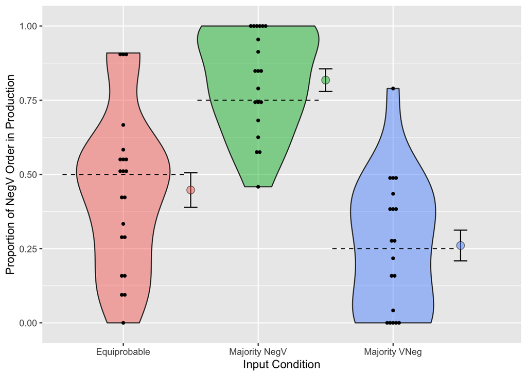

```r
NegVPlot <- ggplot(data=NegV_byp, aes(x=Condition))+
  geom_violin(position=position_dodge(),aes(y=mean_NegV, fill=Condition),show.legend = FALSE, alpha=0.5)+
  geom_errorbar(data=NegV_summary, aes(ymin=input_prop,ymax=input_prop),linetype="dashed", size=.4)+
  geom_errorbar(data=NegV_summary, position=position_nudge(0.5),aes(y=mean, ymin=mean-se,ymax=mean+se),width=0.1)+
  geom_dotplot(position="dodge", aes(y=mean_NegV), dotsize=0.3, binaxis="y", stackdir="center")+
  geom_dotplot(data=NegV_summary, aes(y=mean,fill=Condition), dotsize=0.8, alpha=0.5, binaxis="y", stackdir="center", position_nudge(x=0.5),show.legend = FALSE)+
  labs(x = "Input Condition", y = "Proportion of NegV Order in Production")
NegVPlot

ggsave(filename="Ch3NegVPlot.png",plot=NegVPlot,path=here("figures"),width=6,height=4,units="in")
```

NegV order production in the equiprobable condition is not significantly different from chance.

```r
# find maximal model that will converge
max.model <- NegVorder ~ Condition + (1|participant) + (Condition|item)
negV.m <- buildmer(max.model,data=negProd,family="binomial",buildmerControl=buildmerControl(direction='order', args=list(control=lmerControl(optimizer='bobyqa'))))
# maximal model that will converge:
# NegVorder ~ 1 + condition + (1|participant)
(max.model <- formula(negV.m@model))

negV.m <- glmer(NegVorder~Condition+(1|participant),data=negProd,family="binomial",control=glmerControl(optimizer='bobyqa'))
summary(negV.m)
# a non-significant intercept indicates that the proportion of NegV order productions in the equiprobable condition did not significantly differ from chance
```

```
## NegVorder ~ 1 + Condition + (1 | participant)
## Generalized linear mixed model fit by maximum likelihood (Laplace
##   Approximation) [glmerMod]
##  Family: binomial  ( logit )
## Formula: NegVorder ~ Condition + (1 | participant)
##    Data: negProd
## Control: glmerControl(optimizer = "bobyqa")
##
##      AIC      BIC   logLik deviance df.resid
##   1367.4   1388.2   -679.7   1359.4     1329
##
## Scaled residuals:
##     Min      1Q  Median      3Q     Max
## -3.9184 -0.6338  0.1753  0.5647  3.7830
##
## Random effects:
##  Groups      Name        Variance Std.Dev.
##  participant (Intercept) 2.027    1.424
## Number of obs: 1333, groups:  participant, 60
##
## Fixed effects:
##                        Estimate Std. Error z value Pr(>|z|)
## (Intercept)             -0.2940     0.3315  -0.887   0.3752
## ConditionMajority NegV   2.3255     0.4935   4.713 2.44e-06 ***
## ConditionMajority VNeg  -1.2166     0.4915  -2.475   0.0133 *
## ---
## Signif. codes:  0 '***' 0.001 '**' 0.01 '*' 0.05 '.' 0.1 ' ' 1
##
## Correlation of Fixed Effects:
##             (Intr) CndMNV
## CndtnMjrNgV -0.675
## CndtnMjrtVN -0.672  0.440
```

# 4 Majority Order

No significant difference in production of majority order between ajority NegV Condition and Majority VNeg Condition.

```r
# create majorityOrder column
negProd$majorityOrder <- ifelse(negProd$Condition == "Majority VNeg",
                              ifelse(is.na(negProd$NegVorder), NA,
                                ifelse(negProd$NegVorder == 1, 0, 1)),
                              negProd$NegVorder)

#relevel condition so Majority NegV is reference
negProd$Condition <- relevel(negProd$Condition, ref="Majority NegV")

# find maximal model that will converge
max.model <- majorityOrder ~ Condition + (1|participant) + (Condition|item)
maj.m <- buildmer(max.model,data=negProd,family="binomial",buildmerControl=buildmerControl(direction='order', args=list(control=lmerControl(optimizer='bobyqa'))))
# maximal model that will converge:
# majorityOrder ~ 1 + condition + (1|participant) + (1 | item)
(max.model <- formula(maj.m@model))

maj.m <- glmer(majorityOrder~Condition+(1|participant)+(1|item),data=negProd,family="binomial",control=glmerControl(optimizer='bobyqa'))
summary(maj.m)
```

```
## majorityOrder ~ 1 + Condition + (1 | participant) + (1 | item)
## Generalized linear mixed model fit by maximum likelihood (Laplace
##   Approximation) [glmerMod]
##  Family: binomial  ( logit )
## Formula: majorityOrder ~ Condition + (1 | participant) + (1 | item)
##    Data: negProd
## Control: glmerControl(optimizer = "bobyqa")
##
##      AIC      BIC   logLik deviance df.resid
##   1369.4   1395.3   -679.7   1359.4     1328
##
## Scaled residuals:
##     Min      1Q  Median      3Q     Max
## -3.8957 -0.6261  0.2022  0.5790  2.7509
##
## Random effects:
##  Groups      Name        Variance Std.Dev.
##  participant (Intercept) 2.029827 1.42472
##  item        (Intercept) 0.003853 0.06207
## Number of obs: 1333, groups:  participant, 60; item, 24
##
## Fixed effects:
##                        Estimate Std. Error z value Pr(>|z|)
## (Intercept)              2.0330     0.3648   5.573 2.51e-08 ***
## ConditionEquiprobable   -2.3274     0.4939  -4.712 2.45e-06 ***
## ConditionMajority VNeg  -0.5211     0.5086  -1.025    0.306
## ---
## Signif. codes:  0 '***' 0.001 '**' 0.01 '*' 0.05 '.' 0.1 ' ' 1
##
## Correlation of Fixed Effects:
##             (Intr) CndtnE
## CndtnEqprbb -0.740
## CndtnMjrtVN -0.698  0.516
```